# first-order

## Example 5 - Analyzing data when there are some missing points in the signal

When simulating signals with missing measurements, we show below how the analysis function still manages to retrieve a reasonable accurate fit:

```r
t <- 0:200
data5 <- generate.panel.1order(time = t,
                               excitation = as.numeric(t>50 & t<100),
                               y0 = 0,
                               t0 = 0,
                               exc0 = 0,
                               tau = 10,
                               k = 1,
                               yeq = 0,
                               nind = 6,
                               internoise = 0.4,
                               intranoise = 100)
```

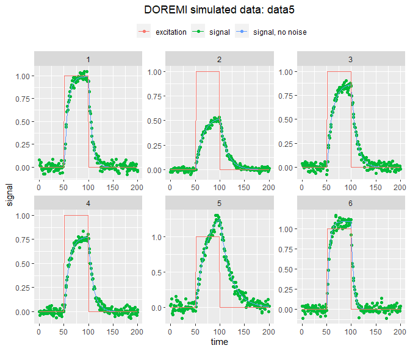

```r
plot(data5)
```

```r
#Keeping one third of the rows selected randomly from the full data set
data5rd <- as.data.table(data5[sample(nrow(data5), nrow(data5)/3), ])
data5rd <- data5rd[order(id,time)]
```

In the next plot we show the selection of random points made on the full data set. The signal without noise has been represented in order show the selection of points made. However, the signal with noise will be used to carry out the analysis.

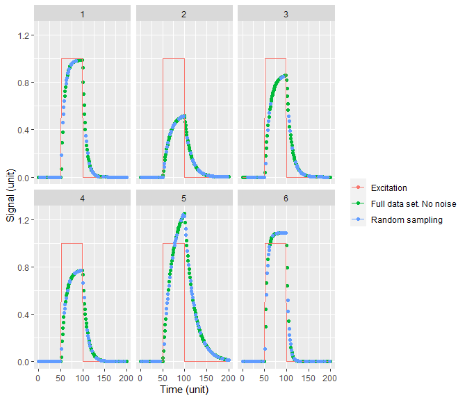

```r
ggplot2::ggplot( data = data5 ) +
  ggplot2::geom_point(ggplot2::aes(time,signalraw, colour = "Full data set. No noise"))+
  ggplot2::geom_line(ggplot2::aes(time,excitation,colour = "Excitation"))+
  ggplot2::geom_point(data = data5rd, ggplot2::aes(time,signalraw, colour = "Random sampling"))+
  ggplot2::facet_wrap(~id)+
  ggplot2::labs(x = "Time (unit)",
           y = "Signal (unit)",
           colour = "")
```

Then analyzing and visualizing the random points selection:

```r
res7 <- analyze.1order(data = data5rd,
                       id = "id",
                       input = "excitation",
                       time ="time",
                       signal = "signal")
```

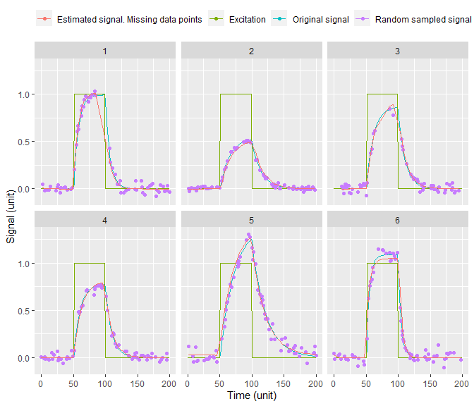

```r
ggplot2::ggplot( data = data5 ) +
  ggplot2::geom_line(ggplot2::aes(time,signalraw, colour = "Original signal"))+
  ggplot2::geom_line(ggplot2::aes(time,excitation,colour = "Excitation"))+
  ggplot2::geom_point(data = data5rd, ggplot2::aes(time,signal, colour = "Random sampled signal"))+
  ggplot2::geom_line(data = res7$data, ggplot2::aes(time,signal_estimated, colour = "Estimated signal. Missing data points"))+
  ggplot2::facet_wrap(~id)+
  ggplot2::labs(x = "Time (unit)",
           y = "Signal (unit)",
           colour = "") +
  ggplot2::theme(legend.position = "top",
        plot.title = element_text(hjust = 0.5))
```

# C - Applications

## Measuring heart frequency during effort tests

Using the `cardio` dataset present in this package, we will apply the model to real heart frequency measurements. The data fields are described with detail in the pdf manual of the package, together with the source from which the data was obtained. In brief, the data consists on heart rate measurements from 21 individuals carrying out an effort test on a cycle ergometer. Participants pedal on a bicycle with increasing resistance. The resistance load is measured in watts, with higher load forcing the individual to greater effort. His/her heart frequency will then vary according to the effort supplied and the participant’s fitness. According to this, the `cardio` data includes, for each individual, the time since the beginning of the test (seconds), the bicycle load (Watts) and the heart rate (1/min).

```r
resc1a <- analyze.1order(data = cardio,
                 id = "id",
                 input = "load",
                 time ="time",
                 signal = "hr",
                 dermethod = "gold",
                 derparam = 5)
```

Plotting analysis results for all 21 participants. Note that omitting the argument `id` would lead to only the first 6 participants being plotted by default.

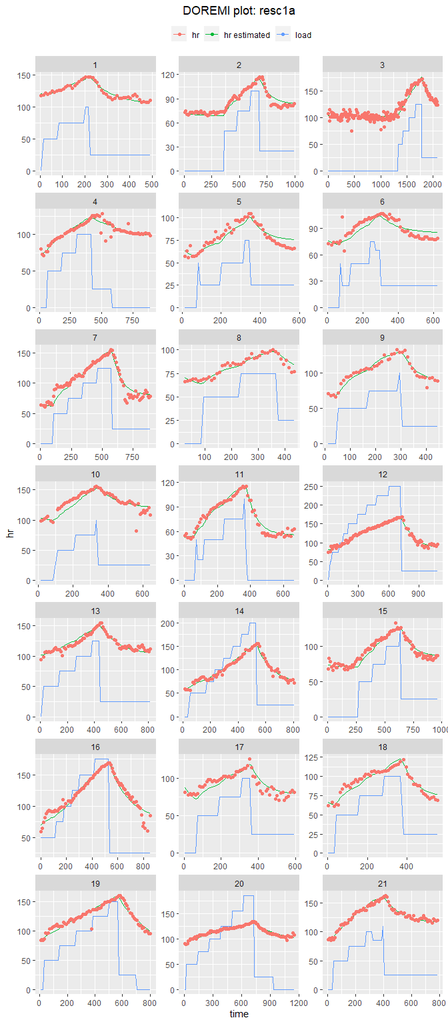

```r
plot(resc1a, id = 1:21) + ggplot2::facet_wrap(~id,ncol=3,scales="free")
```

As can be seen, the model reproduces reasonably well the variation of the heart rate, and can be used to fully characterize the heart rate dynamics with three simple parameters: the resting heart rate (the equilibrium value), the characteristic time of heart rate change (the decay time), and the increase of heart rate for a given effort (the gain).

## Measuring heart frequency during effort tests by considering several excitations

In the previous example, each one of the steps in the resistance load can be considered as a separated perturbation having an effect on heart rate. In this case, the functions will estimate different gains as explained, to account for each one of the contributions of the load to the total heart rate dynamics.

```r
mydata<-cardio

#Decomposing the load
#Maximum number of extra columns to create
Ncol <- max(mydata[,length(unique(load[load != 0])),by = id]$V1)
emptycols<-c(paste0("input",1:Ncol))

# Creating column that contains unique values in load greater than 0 for decomposition
mydata[,Ncol := length(unique(load[load != 0])),by = id]

#Filling the created empty columns with the values
for (i in 1:length(unique(mydata$id))){
  Ncol<-mydata[id==unique(mydata$id)[i],length(unique(load[load != 0]))]
  mydata[id==unique(mydata$id)[i],emptycols[1:Ncol] := lapply(unique(load[load != 0]),function(x){ ifelse(load == x,x,0)}), by = id]
}

resc1b <- analyze.1order(data = mydata,
                        id = "id",
                        input = emptycols,
                        time = "time",
                        signal = "hr",
                        dermethod = "gold",
                        derparam = 5)
```

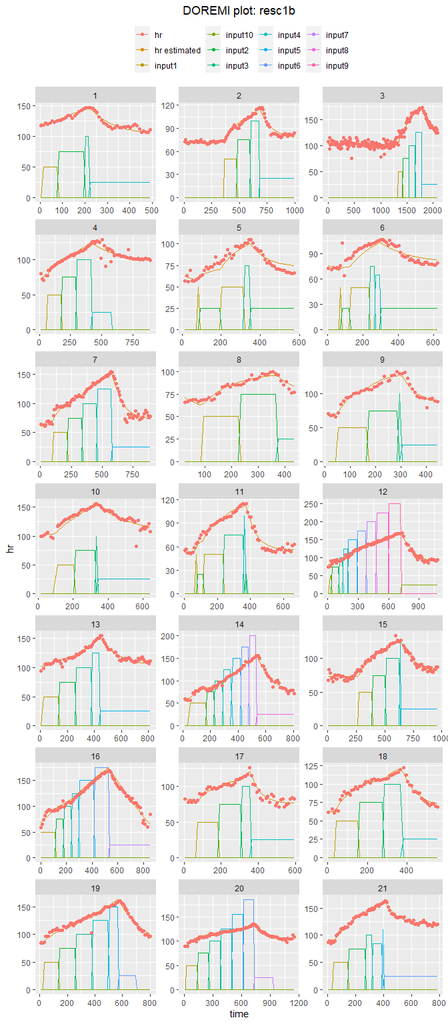

```r
plot(resc1b,id=1:21)+ ggplot2::facet_wrap(~id,ncol=3,scales="free")
```

## Measurements of response time of individuals when carrying out mental rotation tasks

Using the `rotation` dataset present in this package, we will apply the model to a case in which the excitation signal is not clearly defined. In brief, the data is from 17 individuals that carried out mental rotation tasks (identify if two figures, one of which is rotated, are the same or a mirror image) and the response time (in milliseconds) was measured [(Courvoisier et al., 2013)](https://doi.org/10.1016/j.yhbeh.2012.12.007). Each individual was measured every day for 60 days, though there can be missing data. To account for this, the time has been represented by the number of days since the beginning of the experiment (variable `days`). The signal is the mean response time (variable `meanRT`) over the ~200 stimuli done every day. The purpose of the study was to compare the performance between men and women.

```r
dermethod<- "fda"
pmin = 0.1
pmax = 1
pstep = 0.1

restemp <- optimum_param(data = rotation,
                          id = "id",
                          time ="days",
                          signal = "meanRT",
                          dermethod = dermethod,
                          model = "1order",
                          pmin = pmin,
                          pmax = pmax,
                          pstep = pstep)
```

[output not shown]

```r
restemp$summary_opt
resc2a <- analyze.1order(data = rotation,
                 id = "id",
                 time ="days",
                 signal = "meanRT",
                 dermethod = dermethod,
                 derparam = restemp$d)
```

```
#> WARN [2020-07-10 13:11:34] No excitation signal introduced as input. Input was set to 0.
```

Plotting analysis results:

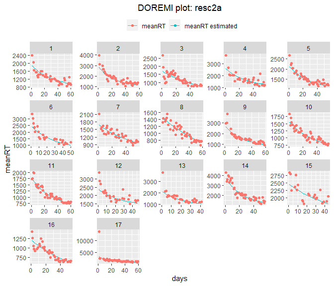

```r
plot(resc2a, id = 1:17)
```

# D - Print, summary, plot and predict with doremi objects

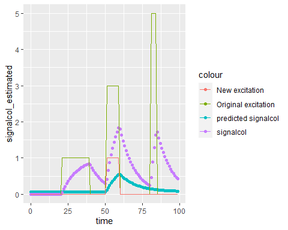

```r
#Input data from previous example
datad1<-setDT(data4)[id==1,.(id,time,excitation,signalcol)]

#Analysis
resd1 <- analyze.1order(data = datad1,
                        input = "excitation",
                        time = "time",
                        signal = "signalcol",
                        dermethod = "glla",
                        derparam = 7)

#Creating data frame with et2 that will be supplied as new excitation for the predict function
datad1n <- copy(datad1)
datad1n$excitation <- as.numeric(datad1$time>50 & datad1$time<60)


#Calling the predict function
predresd1<- predict(resd1,
                    newdata = datad1n)

#Comparing predicted value with signal y2
ggplot2::ggplot(data = predresd1$data) +
ggplot2::geom_point(ggplot2::aes(time, signalcol_estimated,colour = "predicted signalcol")) +
ggplot2::geom_point(ggplot2::aes(time, signalcol,colour = "signalcol")) +
ggplot2::geom_line(data= datad1, ggplot2::aes(time, excitation,colour = "Original excitation")) +
ggplot2::geom_line(data= datad1n, ggplot2::aes(time, excitation,colour = "New excitation"))
```